# Case Study - Cyclistic

David Zapata

2024-03-23

## **Introduction**

*Cyclistic* is a fictional bike-share company, that believes that maximizing the number of annual memberships is key for the company ’s future success.This case study is about understanding how casual riders and annual members use *Cyclistic* bikes differently.

This work is divided in the data analysis process phases: **Ask, Prepare, Process, Analyse, Share and Act.**

This case study has been done using **R** language and **Markdown**

## ❓ **Ask**

### **Busines Task**

The primary objective of this analysis is to determine how casual costumers are using *Cyclistic* bikes compared to subscribed members, in order to design a new marketing strategy that will focus on converting casual riders into annual members.

#### **Main stakeholders**

- *Lily Moreno*: The director of marketing. Responsible for the development of campaigns and initiatives to promote the bike-share program.
- *Cyclistic marketing analytics team:* Responsible for collecting, analyzing, and reporting data that helps guide *Cyclistic* marketing strategy.
- *Cyclistic executive team:* The notoriously detail-oriented executive team will decide whether to approve the recommended marketing program.

## 🧰️ **Prepare**

### **About the source data**

Last 12 months (from March 2023 to February 2024) of Cyclistic’s historical trip data has been collected on a monthly basis in CSV files with the format **`YYYY_MM_tripdata.csv`**, and saved in a common folder.

The [data](https://divvy-tripdata.s3.amazonaws.com/index.html) has been made available by Motivate International Inc. under this [license](https://divvybikes.com/data-license-agreement).

### **Prepare data**

Instead of using spreadsheets to process each individual CSV file, these files have been imported and merged in one big dataframe called *`combined_data`*.

```r
#import data
csv_files <- list.files(path = "./data/raw", pattern = "*.csv", full.names = TRUE)
combined_data <- readr::read_csv(csv_files, id = "file_name")
```

```r
glimpse(combined_data)
```

```
## Rows: 5,707,168
## Columns: 14
## $ file_name          <chr> "./data/raw/2023_03_tripdata.csv", "./data/raw/2023…
## $ ride_id            <chr> "6842AA605EE9FBB3", "F984267A75B99A8C", "FF7CF57CFE…
## $ rideable_type      <chr> "electric_bike", "electric_bike", "classic_bike", "…
## $ started_at         <dttm> 2023-03-16 08:20:34, 2023-03-04 14:07:06, 2023-03-…
## $ ended_at           <dttm> 2023-03-16 08:22:52, 2023-03-04 14:15:31, 2023-03-…
## $ start_station_name <chr> "Clark St & Armitage Ave", "Public Rack - Kedzie Av…
## $ start_station_id   <chr> "13146", "491", "620", "TA1306000003", "18067", "62…
## $ end_station_name   <chr> "Larrabee St & Webster Ave", NA, "Clark St & Randol…
## $ end_station_id     <chr> "13193", NA, "TA1305000030", "13154", "TA1306000015…
## $ start_lat          <dbl> 41.91841, 41.97000, 41.89820, 41.88872, 41.91448, 4…
## $ start_lng          <dbl> -87.63645, -87.71000, -87.63754, -87.64445, -87.668…
## $ end_lat            <dbl> 41.92182, 41.95000, 41.88458, 41.91052, 41.88578, 4…
## $ end_lng            <dbl> -87.64414, -87.71000, -87.63189, -87.65311, -87.651…
## $ member_casual      <chr> "member", "member", "member", "member", "member", "…
```

The resulting dataframe is too big to be loaded into a spreadsheet (rows). This case study is made using R, but a more optimal tool would have been using SQL, as it is designed to handle big volumes of data.

## 🛠 **Process**

Inspecting the current data, it has the ride starting and ending locations several times in different formats (station Id, station_name and coordinates), this might be useful at the time of cleaning the data in case any piece of information is missing, and to check the data consistency.

The first step is to select the columns of interest. This is specially useful to reduce memory use and therefore speed up the processing times, but the main reason is to set a focus on answering this project’s questions.

```r
data <- combined_data %>%
  select(rideable_type,
         started_at,
         ended_at,
         start_station_name,
         end_station_name,
         member_casual)
```

### **Formatting data**

With a smaller dataframe, some useful columns have been added to help with this analysis:

- **`duration`**: duration of a ride in minutes.
- **`day_of_the_week`** and **`month`**: to be able to aggregate the data based on these columns

```r
data <- data %>%
  mutate(duration = as.numeric(ended_at - started_at)/60) %>% # cast as numeric to be able to run calculations
  mutate(day_of_the_week = weekdays(started_at)) %>%
  mutate(month = month(started_at, label = TRUE, abbr = TRUE))
```

Some formatting is needed in some columns. **`days_of_the week`** and **`month`** need to be ordered (Note that the oldest data is from March 2023).

Also the column **`member_casual`** need to be a factor with levels: **`member`** and **`casual`**

```r
data$day_of_the_week <-
  ordered(data$day_of_the_week,
          levels=c("Monday", "Tuesday", "Wednesday", "Thursday", "Friday", "Saturday", "Sunday"))
data$member_casual <- as.factor(data$member_casual)
```

### **Cleaning data**

#### *Missing data*

Next, the data frame has been checked for missing values:

```r
data %>% skim_without_charts() %>%
  dplyr::filter(n_missing > 0)
```

Data summary

| Name | Piped data |
| --- | --- |
| Number of rows | 5707168 |
| Number of columns | 9 |
| _______________________ |  |
| Column type frequency: |  |
| character | 2 |
| ________________________ |  |
| Group variables | None |

**Variable type: character**

| skim_variable | n_missing | complete_rate | min | max | empty | n_unique | whitespace |
| --- | --- | --- | --- | --- | --- | --- | --- |
| start_station_name | 866105 | 0.85 | 3 | 64 | 0 | 1595 | 0 |
| end_station_name | 920524 | 0.84 | 3 | 64 | 0 | 1606 | 0 |

Columns **`start_station_name`** and **`end_station_name`** have missing values.

Exploring columns in the original dataset **`combined_data`**: **`start_station_name`**, **`start_station_id`**, **`start_lat`**, **`start_lng`**, and filtering the rows with missing values will give a better perspective:

```r
start_station_na <- combined_data %>%
  select(start_station_name, start_station_id, start_lat, start_lng) %>%
  filter(is.na(start_station_name))

head(start_station_na)
```

```
## # A tibble: 6 × 4
##   start_station_name start_station_id start_lat start_lng
##   <chr>              <chr>                <dbl>     <dbl>
## 1 <NA>               <NA>                  41.9     -87.7
## 2 <NA>               <NA>                  41.9     -87.6
## 3 <NA>               <NA>                  41.9     -87.7
## 4 <NA>               <NA>                  41.9     -87.6
## 5 <NA>               <NA>                  41.9     -87.7
## 6 <NA>               <NA>                  41.9     -87.6
```

It looks like **`start_station_name`** and **`start_station_id`** are determined by the GPS coordinates. As the coordinates values don’t have enough decimal points, it is not possible to identify the station location. This GPS error happens mostly with electric bikes.

As this is still valid data, the missing values are then replaced with an “Unknown” string:

```r
data$start_station_name <- ifelse(is.na(data$start_station_name), "Unknown", data$start_station_name)
data$end_station_name <- ifelse(is.na(data$end_station_name), "Unknown", data$end_station_name)
```

#### *Docked bikes*

The column **`rideable_type`** have three levels: **`clasical_bike`**, **`electric_bike`** and **`docked_bike`**, exploring more about the docked bikes:

```r
docked_data <- filter(data,rideable_type=="docked_bike")
docked_data$duration <- as.integer(docked_data$duration)
aggregate(docked_data$duration ~ docked_data$member_casual+docked_data$month, FUN = median)
```

```
##   docked_data$member_casual docked_data$month docked_data$duration
## 1                    casual               Mar                   21
## 2                    casual               Apr                   28
## 3                    casual               May                   29
## 4                    casual               Jun                   28
## 5                    casual               Jul                   30
## 6                    casual               Aug                   29
```

**Assumption 1:** According with the data, docked bikes are exclusively used by casual users and they are only used during the spring and summer seasons (March to August). This analysis assumes that these are pedal bikes, similar to the classic bikes, only that they need to be picked up and returned to a specific docking station.

```r
data <-  data %>%
  mutate(rideable_type = recode(rideable_type,"docked_bike" = "classic_bike"))
```

#### *Negative ride lengths*

```r
data_clean <- filter(data, !(duration < 0))
```

#### *False positives*

**Assumption 2:** Rides that start and end at the same location and last less than 3 minutes are not considered for this case study.

```r
data_clean <- filter(data_clean, !((start_station_name == end_station_name) & duration <= 3))
```

A final check of the data is performed:

```r
skim_without_charts(data_clean)
```

Data summary

| Name | data_clean |
| --- | --- |
| Number of rows | 5512873 |
| Number of columns | 9 |
| _______________________ |  |
| Column type frequency: |  |
| character | 3 |
| factor | 3 |
| numeric | 1 |
| POSIXct | 2 |
| ________________________ |  |
| Group variables | None |

**Variable type: character**

| skim_variable | n_missing | complete_rate | min | max | empty | n_unique | whitespace |
| --- | --- | --- | --- | --- | --- | --- | --- |
| rideable_type | 0 | 1 | 12 | 13 | 0 | 2 | 0 |
| start_station_name | 0 | 1 | 3 | 64 | 0 | 1592 | 0 |
| end_station_name | 0 | 1 | 3 | 64 | 0 | 1601 | 0 |

**Variable type: factor**

| skim_variable | n_missing | complete_rate | ordered | n_unique | top_counts |
| --- | --- | --- | --- | --- | --- |
| member_casual | 0 | 1 | FALSE | 2 | mem: 3545218, cas: 1967655 |
| day_of_the_week | 0 | 1 | TRUE | 7 | Thu: 852884, Sat: 838052, Wed: 818909, Fri: 814089 |
| month | 0 | 1 | TRUE | 12 | Aug: 746465, Jul: 740276, Jun: 694982, Sep: 645958 |

**Variable type: numeric**

| skim_variable | n_missing | complete_rate | mean | sd | p0 | p25 | p50 | p75 | p100 |
| --- | --- | --- | --- | --- | --- | --- | --- | --- | --- |
| duration | 0 | 1 | 18.94 | 181 | 0 | 5.83 | 9.93 | 17.4 | 98489.07 |

**Variable type: POSIXct**

| skim_variable | n_missing | complete_rate | min | max | median | n_unique |
| --- | --- | --- | --- | --- | --- | --- |
| started_at | 0 | 1 | 2023-03-01 00:00:50 | 2024-02-29 23:59:15 | 2023-08-04 03:33:49 | 4671225 |
| ended_at | 0 | 1 | 2023-03-01 00:04:17 | 2024-03-01 23:51:12 | 2023-08-04 05:09:25 | 4682783 |

## 📊 **Analyze**

With the data cleaned and prepared, the analysis starts with a quick overview of the ride length:

```r
summary(data_clean$duration)
```

```
##      Min.   1st Qu.    Median      Mean   3rd Qu.      Max.
##     0.000     5.833     9.933    18.941    17.400 98489.067
```

Comparing the casual and member users:

```r
rides_per_user_pivot <- data_clean %>%
  group_by(member_casual) %>%
  summarise(number_of_rides = n(),
            average_duration = round(mean(duration),2))%>%
  mutate(n_rides_pct = round(number_of_rides/sum(number_of_rides)*100, 2)) #number of rides as percentage

print(rides_per_user_pivot)
```

```
## # A tibble: 2 × 4
##   member_casual number_of_rides average_duration n_rides_pct
##   <fct>                   <int>            <dbl>       <dbl>
## 1 casual                1967655             29.4        35.7
## 2 member                3545218             13.1        64.3
```

Average duration and the number of rides per type of bike, per type of user:

```r
rides_per_rideable_pivot <- data_clean %>%
  group_by(member_casual, rideable_type) %>%
  summarise(number_of_rides = n(),
            average_duration = mean(duration))%>%
  mutate(n_rides_pct = round(number_of_rides/sum(number_of_rides)*100, 2))
print(rides_per_rideable_pivot)
```

```
## # A tibble: 4 × 5
## # Groups:   member_casual [2]
##   member_casual rideable_type number_of_rides average_duration n_rides_pct
##   <fct>         <chr>                   <int>            <dbl>       <dbl>
## 1 casual        classic_bike           935192             45.3        47.5
## 2 casual        electric_bike         1032463             15.0        52.5
## 3 member        classic_bike          1812722             14.5        51.1
## 4 member        electric_bike         1732496             11.7        48.9
```

Average duration and the number of rides per week days, per type of user:

```r
rides_per_wday_pivot <- data_clean %>%
  group_by(member_casual, day_of_the_week) %>%
  summarise(number_of_rides = n(),
            average_duration = mean(duration)) %>%
  arrange(day_of_the_week, member_casual)
head(rides_per_wday_pivot)
```

```
## # A tibble: 6 × 4
## # Groups:   member_casual [2]
##   member_casual day_of_the_week number_of_rides average_duration
##   <fct>         <ord>                     <int>            <dbl>
## 1 casual        Monday                   223891             29.1
## 2 member        Monday                   478282             12.5
## 3 casual        Tuesday                  234399             26.3
## 4 member        Tuesday                  552253             12.7
## 5 casual        Wednesday                240411             25.3
## 6 member        Wednesday                578498             12.6
```

Average duration and the number of rides per month, per type of user:

```r
rides_per_month_pivot <- data_clean %>%
  group_by(member_casual, month) %>%
  summarise(number_of_rides = n(),
            average_duration = mean(duration)) %>%
  arrange(month, member_casual)
head(rides_per_month_pivot)
```

```
## # A tibble: 6 × 4
## # Groups:   member_casual [2]
##   member_casual month number_of_rides average_duration
##   <fct>         <ord>           <int>            <dbl>
## 1 casual        Jan             23366             22.3
## 2 member        Jan            115756             14.3
## 3 casual        Feb             45728             25.9
## 4 member        Feb            172293             13.2
## 5 casual        Mar             59420             22.4
## 6 member        Mar            188599             10.8
```

## 📢 **Share**

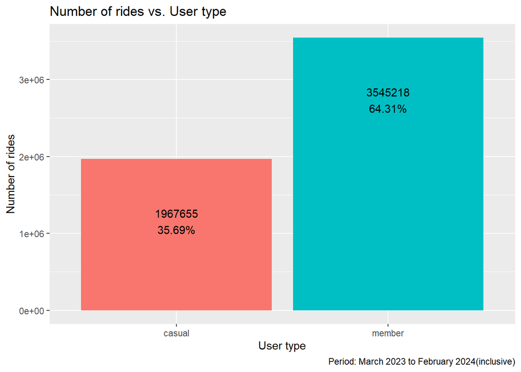

```r
#### Number of rides per user type ####
ggplot(data=rides_per_user_pivot)+
  geom_col(mapping = aes(x = member_casual, y = number_of_rides, fill = member_casual),
           position = position_dodge())+
  geom_text(aes(x = member_casual, y = number_of_rides,
                label =  paste0(number_of_rides,"\n",n_rides_pct, "%") ), vjust = 3, hjust = 0.5)+
  theme(legend.position = "none")+
  labs(title="Number of rides vs. User type",
       caption = "Period: March 2023 to February 2024(inclusive)",
       y = "Number of rides", x = "User type", fill = "User Type")
```

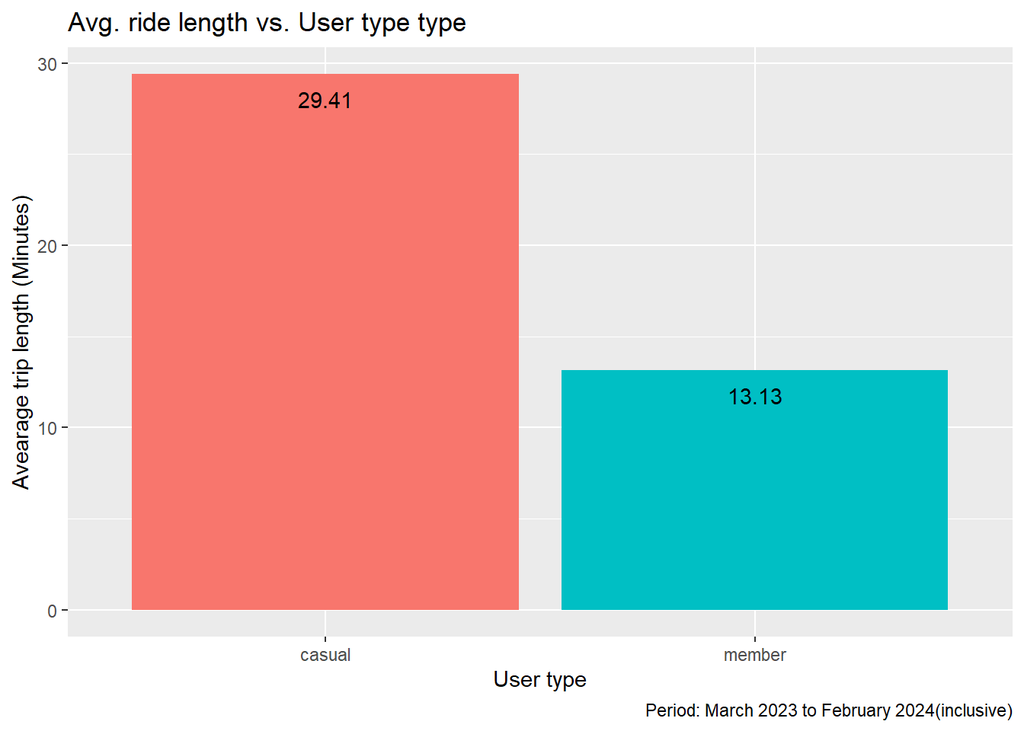

```r
#### Average ride length per user type ####
ggplot(data=rides_per_user_pivot)+
  geom_col(mapping = aes(x = member_casual, y = average_duration, fill = member_casual), position = position_dodge())+
  geom_text(aes(x = member_casual, y = average_duration,label = average_duration ), vjust = 2, hjust = 0.5)+
  theme(legend.position = "none")+
  labs(title="Avg. ride length vs. User type type",
       #subtitle = "Cyclistic",
       caption = "Period: March 2023 to February 2024(inclusive)",
       y = "Avearage trip length (Minutes)",
       x = "User type",
       fill = "User Type")
```

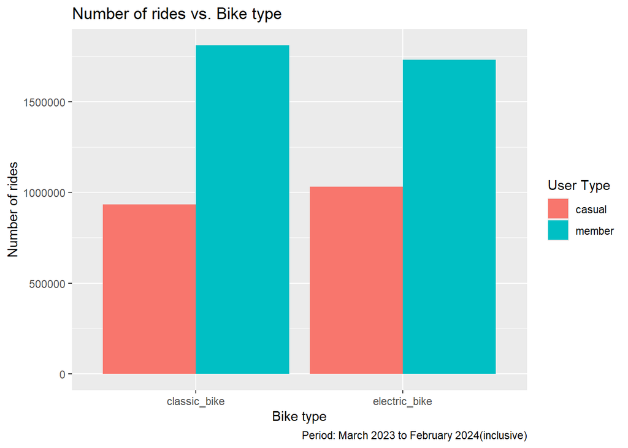

```r
#### Number of rides per bike type per user type ####
ggplot(data = rides_per_rideable_pivot)+
  geom_col(mapping = aes(x = rideable_type, y = number_of_rides, fill = member_casual), position = position_dodge()) +
  labs(title="Number of rides vs. Bike type",
       #subtitle = "Cyclistic",
       caption = "Period: March 2023 to February 2024(inclusive)",
       y = "Number of rides",
       x = "Bike type",
       fill = "User Type")
```

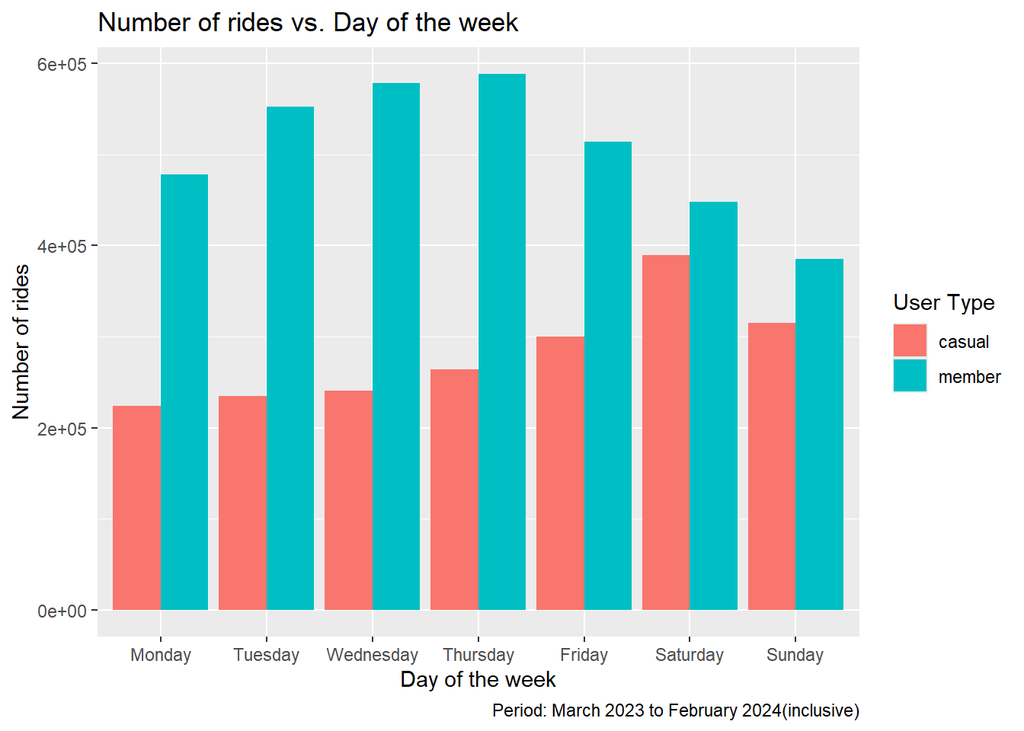

```r
#### Number of rides per day of the week per user type ####
ggplot(rides_per_wday_pivot, aes(x = day_of_the_week, y = number_of_rides, fill = member_casual)) +
  geom_col(position = "dodge")+
  labs(y = "Number of Rides")+
  labs(title="Number of rides vs. Day of the week",
       caption = "Period: March 2023 to February 2024(inclusive)",
       y = "Number of rides",
       x = "Day of the week",
       fill = "User Type")
```

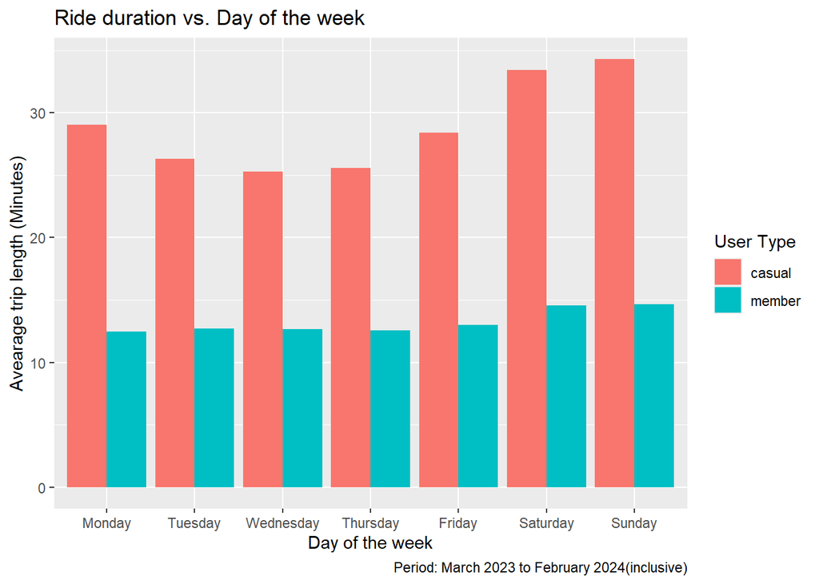

```r
#### Average ride length per day of the week per user type ####
ggplot(rides_per_wday_pivot, aes(x = day_of_the_week, y = average_duration, fill = member_casual)) +
  geom_col(position = "dodge") +
  labs(title="Ride duration vs. Day of the week",
       #subtitle = "Cyclistic",
       caption = "Period: March 2023 to February 2024(inclusive)",
       y = "Avearage trip length (Minutes)",
       x = "Day of the week",
       fill = "User Type")
```

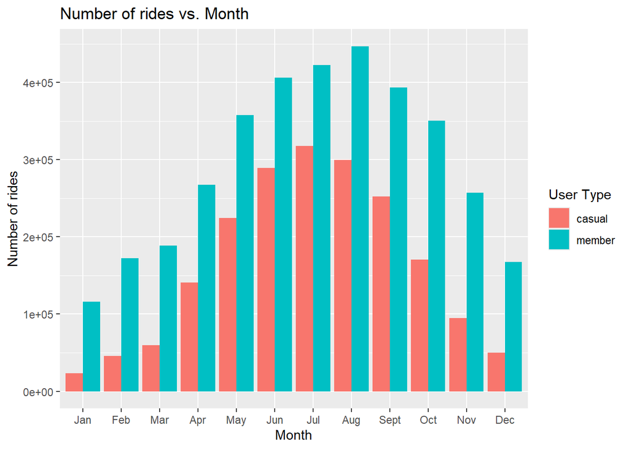

```r
#### Number of rides per month per user type ####
ggplot(data = rides_per_month_pivot)+
  geom_col(mapping = aes(x = month, y = number_of_rides, fill = member_casual), position = position_dodge())+
  labs(title="Number of rides vs. Month",
       y = "Number of rides",
       x = "Month",
       fill = "User Type")
```

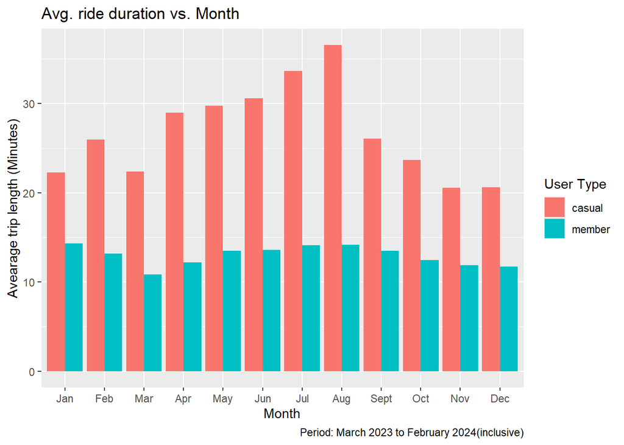

```r
#### Average ride length per day of the week per user type ####
ggplot(rides_per_month_pivot, aes(x = month, y = average_duration, fill = member_casual)) +
  geom_col(position = "dodge") +
  labs(title="Avg. ride duration vs. Month",
       #subtitle = "Cyclistic",
       caption = "Period: March 2023 to February 2024(inclusive)",
       y = "Avearage trip length (Minutes)",
       x = "Month",
       fill = "User Type")
```

## 🚀 **Act**

### **Recommendations**

- To run the user conversion campaigns during the weekends, specially on Saturdays, where most of the casual users are using the *Cyclistic* bikes.
- Spring and Summer are the seasons where most users, casual and members, use *Cyclistic* services. It is the best time to do the marketing campaign outside and close to the stations.
- As casual users make longer bike rides for leisure on average, the campaign should put emphasis on:
  - The benefits of a membership from a cost per minute perspective compared to the single casual use.
  - The reduced cost for electric bikes compared to the single casual cost.
  - The benefits of using the bike as a regular mean of transportation, not only to keep healthy habits, but also for economic reasons.

### **Further Analysis**

It would be worthy to spend time analyzing the stations and their closeness to places of interest and see the difference between casual and membership users.